# Crude Oil Production and Evacuation Analytics: Drivers of Zone-Level Throughput Performance

## 9 Multiple Regression

**Theory recap:** Ordinary Least Squares (OLS) regression estimates the linear combination of predictors that minimises the sum of squared residuals. Key assumptions: linearity, independence of errors, homoscedasticity, approximate normality of residuals, and no severe multicollinearity. Violation of these assumptions affects the reliability of coefficient estimates and their standard errors. Diagnostics include residual plots (linearity, homoscedasticity), Q-Q plots (normality), Cook’s distance (influential observations), Variance Inflation Factors (multicollinearity), and the Durbin-Watson statistic (autocorrelation).

**Business justification:** Quantifies the independent contribution of zone, evacuation capacity, and utilization to daily production shortfall. The resulting coefficients support concrete fleet-sizing and capacity-allocation recommendations to management.

**R**

```r
df_r$ZONE_f <- factor(df_r$ZONE)

model <- lm(shortfall_zone ~ ZONE_f + evacuation_capacity + utilization_rate,
            data = df_r)

cat("=== OLS Regression: Daily Zone Shortfall ===\n")
```

```
=== OLS Regression: Daily Zone Shortfall ===
```

```r
summary(model)
```

```
Call:
lm(formula = shortfall_zone ~ ZONE_f + evacuation_capacity +
    utilization_rate, data = df_r)

Residuals:
    Min      1Q  Median      3Q     Max
-9226.8 -1480.3  -206.3  1481.0  9262.5

Coefficients:
                      Estimate Std. Error t value Pr(>|t|)
(Intercept)         2856.66619 1737.79253   1.644    0.102
ZONE_fZONE 2        2987.76348  524.33100   5.698 3.59e-08 ***
evacuation_capacity   -0.56020    0.07534  -7.436 1.91e-12 ***
utilization_rate     861.67142 2759.28188   0.312    0.755
---
Signif. codes:  0 '***' 0.001 '**' 0.01 '*' 0.05 '.' 0.1 ' ' 1

Residual standard error: 3251 on 236 degrees of freedom
  (10 observations deleted due to missingness)
Multiple R-squared:  0.2904,    Adjusted R-squared:  0.2813
F-statistic: 32.19 on 3 and 236 DF,  p-value: < 2.2e-16
```

```r
coef_data <- data.frame(
  term      = names(coef(model)),
  estimate  = coef(model),
  std.error = sqrt(diag(vcov(model))),
  row.names = NULL
)
coef_data$t.value  <- coef_data$estimate / coef_data$std.error
coef_data$p.value  <- 2 * pt(abs(coef_data$t.value), df = model$df.residual,
                               lower.tail = FALSE)
coef_data$conf.low  <- coef_data$estimate - 1.96 * coef_data$std.error
coef_data$conf.high <- coef_data$estimate + 1.96 * coef_data$std.error
coef_data[, -1] <- round(coef_data[, -1], 4)

kable(coef_data, caption = "Regression coefficients with 95% confidence intervals") |>
  kable_styling(bootstrap_options = "striped", full_width = FALSE)
```

Regression coefficients with 95% confidence intervals

| term | estimate | std.error | t.value | p.value | conf.low | conf.high |
| --- | --- | --- | --- | --- | --- | --- |
| (Intercept) | 2856.6662 | 1737.7925 | 1.6438 | 0.1015 | -549.4072 | 6262.7396 |
| ZONE_fZONE 2 | 2987.7635 | 524.3310 | 5.6982 | 0.0000 | 1960.0747 | 4015.4522 |
| evacuation_capacity | -0.5602 | 0.0753 | -7.4359 | 0.0000 | -0.7079 | -0.4125 |
| utilization_rate | 861.6714 | 2759.2819 | 0.3123 | 0.7551 | -4546.5211 | 6269.8639 |

```r
model_summary <- summary(model)
fit_data <- data.frame(
  r.squared     = round(model_summary$r.squared, 4),
  adj.r.squared = round(model_summary$adj.r.squared, 4),
  fstatistic    = round(model_summary$fstatistic[1], 4),
  p.value       = round(pf(model_summary$fstatistic[1], model_summary$fstatistic[2],
                            model_summary$fstatistic[3], lower.tail = FALSE), 6),
  AIC = round(AIC(model), 2),
  BIC = round(BIC(model), 2)
)
kable(fit_data, caption = "Model fit statistics") |>
  kable_styling(full_width = FALSE)
```

Model fit statistics

|  | r.squared | adj.r.squared | fstatistic | p.value | AIC | BIC |
| --- | --- | --- | --- | --- | --- | --- |
| value | 0.2904 | 0.2813 | 32.1862 | 0 | 4568.61 | 4586.01 |

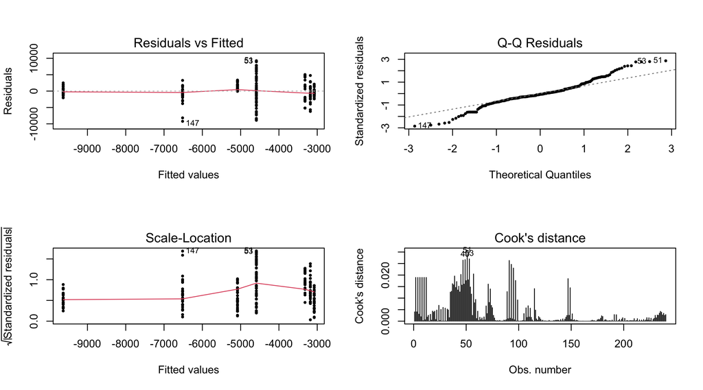

```r
par(mfrow = c(2, 2))
plot(model, which = 1:4, pch = 16, cex = 0.6)
```

```r
par(mfrow = c(1, 1))
```

```r
# VIF — manual computation (no car package required)
X_mat <- model.matrix(model)[, -1]
vif_vals <- sapply(seq_len(ncol(X_mat)), function(i) {
  r2_i <- summary(lm(X_mat[, i] ~ X_mat[, -i]))$r.squared
  1 / (1 - r2_i)
})
names(vif_vals) <- colnames(X_mat)
cat("=== Variance Inflation Factors (VIF) ===\n")
```

```
=== Variance Inflation Factors (VIF) ===
```

```r
print(round(vif_vals, 3))
```

```
       ZONE_fZONE 2 evacuation_capacity    utilization_rate
              1.561               1.033               1.585
```

```r
cat("Note: VIF > 5 = problematic multicollinearity; > 10 = severe\n\n")
```

```
Note: VIF > 5 = problematic multicollinearity; > 10 = severe
```

```r
# Durbin-Watson
resids <- residuals(model)
dw_stat <- sum(diff(resids)^2) / sum(resids^2)
cat(sprintf("=== Durbin-Watson Statistic: %.4f ===\n", dw_stat))
```

```
=== Durbin-Watson Statistic: 0.6362 ===
```

```r
cat(ifelse(dw_stat < 1.5,
  "CAUTION: Positive autocorrelation — OLS SEs may be underestimated; consider robust SEs.\n",
  ifelse(dw_stat > 2.5, "CAUTION: Negative autocorrelation.\n",
  "No strong autocorrelation at this threshold.\n")))
```

```
CAUTION: Positive autocorrelation — OLS SEs may be underestimated; consider robust SEs.
```

```r
# Newey-West HAC robust standard errors (acts on the autocorrelation warning)
hac_vcov <- sandwich::NeweyWest(model, lag = 5, prewhite = FALSE, adjust = TRUE)
hac_test <- lmtest::coeftest(model, vcov. = hac_vcov)
cat("\n=== HAC (Newey-West) Robust Coefficients ===\n")
```

```
=== HAC (Newey-West) Robust Coefficients ===
```

```r
print(round(hac_test, 4))
```

```
t test of coefficients:

                     Estimate Std. Error t value Pr(>|t|)
(Intercept)         2856.6662  4077.7371  0.7006   0.4843
ZONE_fZONE 2        2987.7635   636.4891  4.6941   <2e-16 ***
evacuation_capacity   -0.5602     0.1215 -4.6095   <2e-16 ***
utilization_rate     861.6714  4434.7019  0.1943   0.8461
---
Signif. codes:  0 '***' 0.001 '**' 0.01 '*' 0.05 '.' 0.1 ' ' 1
```

```r
cap_beta_hac <- unname(hac_test["evacuation_capacity", "Estimate"])
cap_se_hac <- unname(hac_test["evacuation_capacity", "Std. Error"])
cap_ci_hac <- cap_beta_hac + c(-1.96, 1.96) * cap_se_hac
```

```r
# Out-of-sample validation: train on Jan-Mar, test on Apr-May
split_date <- as.Date("2026-03-31")
train_r <- df_r |> filter(DATE <= split_date)
test_r  <- df_r |> filter(DATE > split_date)

model_train_r <- lm(shortfall_zone ~ ZONE_f + evacuation_capacity + utilization_rate,
                    data = train_r)
pred_test_r <- predict(model_train_r, newdata = test_r)

rmse_r <- sqrt(mean((test_r$shortfall_zone - pred_test_r)^2, na.rm = TRUE))
mae_r  <- mean(abs(test_r$shortfall_zone - pred_test_r), na.rm = TRUE)

cat("=== Holdout Validation (Train Jan-Mar | Test Apr-May) ===\n")
```

```
=== Holdout Validation (Train Jan-Mar | Test Apr-May) ===
```

```r
cat(sprintf("RMSE: %.2f bbl/day | MAE: %.2f bbl/day | Test n: %d\n",
            rmse_r, mae_r, nrow(test_r)))
```

```
RMSE: 3746.13 bbl/day | MAE: 3572.78 bbl/day | Test n: 70
```

```r
cat(sprintf("Capacity coefficient stability (full vs train): %.4f vs %.4f\n",
            coef(model)["evacuation_capacity"],
            coef(model_train_r)["evacuation_capacity"]))
```

```
Capacity coefficient stability (full vs train): -0.5602 vs -1.0361
```

```r
# Capacity intervention scenario ranges from HAC-adjusted uncertainty
scenario_df <- tibble(
  capacity_increase = c(5000, 10000, 15000)
) |>
  mutate(
    daily_recovery_est = -cap_beta_hac * capacity_increase,
    daily_recovery_low = -cap_ci_hac[2] * capacity_increase,
    daily_recovery_high = -cap_ci_hac[1] * capacity_increase,
    annual_recovery_est = daily_recovery_est * 365,
    annual_recovery_pct_18m = annual_recovery_est / 18000000 * 100
  )

kable(
  scenario_df |>
    mutate(across(where(is.numeric), ~ round(., 2))),
  caption = "Capacity expansion scenarios with HAC-based uncertainty bounds"
) |>
  kable_styling(bootstrap_options = "striped", full_width = FALSE)
```

Capacity expansion scenarios with HAC-based uncertainty bounds

| capacity_increase | daily_recovery_est | daily_recovery_low | daily_recovery_high | annual_recovery_est | annual_recovery_pct_18m |
| --- | --- | --- | --- | --- | --- |
| 5000 | 2801.01 | 1609.98 | 3992.03 | 1022367 | 5.68 |
| 10000 | 5602.01 | 3219.97 | 7984.06 | 2044734 | 11.36 |
| 15000 | 8403.02 | 4829.95 | 11976.08 | 3067101 | 17.04 |

**Python**

```python
df_reg = df_py.dropna(subset=["shortfall_zone", "evacuation_capacity",
                               "utilization_rate", "ZONE"])
df_reg = df_reg.copy()
df_reg["ZONE_f"] = pd.Categorical(df_reg["ZONE"])

model_py = smf.ols(
    "shortfall_zone ~ C(ZONE_f) + evacuation_capacity + utilization_rate",
    data=df_reg
).fit()
print(model_py.summary())
```

```
                            OLS Regression Results
==============================================================================
Dep. Variable:         shortfall_zone   R-squared:                       0.290
Model:                            OLS   Adj. R-squared:                  0.281
Method:                 Least Squares   F-statistic:                     32.19
Date:                Wed, 20 May 2026   Prob (F-statistic):           1.77e-17
Time:                        14:51:22   Log-Likelihood:                -2279.3
No. Observations:                 240   AIC:                             4567.
Df Residuals:                     236   BIC:                             4581.
Df Model:                           3
Covariance Type:            nonrobust
=======================================================================================
                          coef    std err          t      P>|t|      [0.025      0.975]
---------------------------------------------------------------------------------------
Intercept            2856.6662   1737.793      1.644      0.102    -566.901    6280.234
C(ZONE_f)[T.ZONE 2]  2987.7635    524.331      5.698      0.000    1954.796    4020.731
evacuation_capacity    -0.5602      0.075     -7.436      0.000      -0.709      -0.412
utilization_rate      861.6714   2759.282      0.312      0.755   -4574.298    6297.641
==============================================================================
Omnibus:                        8.336   Durbin-Watson:                   0.636
Prob(Omnibus):                  0.015   Jarque-Bera (JB):               13.090
Skew:                           0.172   Prob(JB):                      0.00144
Kurtosis:                       4.091   Cond. No.                     2.58e+05
==============================================================================

Notes:
[1] Standard Errors assume that the covariance matrix of the errors is correctly specified.
[2] The condition number is large, 2.58e+05. This might indicate that there are
strong multicollinearity or other numerical problems.
```

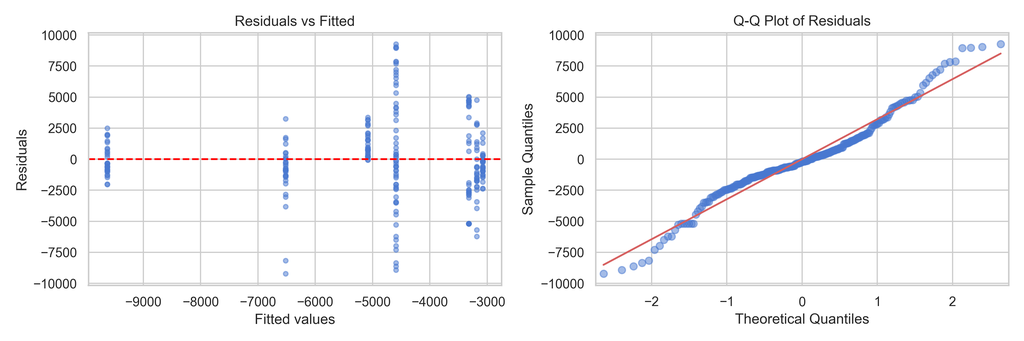

```python
fig, axes = plt.subplots(1, 2, figsize=(12, 4))

axes[0].scatter(model_py.fittedvalues, model_py.resid, alpha=0.5, s=15)
axes[0].axhline(0, color="red", linestyle="--")
axes[0].set_xlabel("Fitted values")
axes[0].set_ylabel("Residuals")
axes[0].set_title("Residuals vs Fitted")

sm.qqplot(model_py.resid, line="s", ax=axes[1], alpha=0.5)
axes[1].set_title("Q-Q Plot of Residuals")

plt.tight_layout()
plt.show()
```

```python
print(f"R-squared: {model_py.rsquared:.4f}")
```

```
R-squared: 0.2904
```

```python
print(f"Adj. R-squared: {model_py.rsquared_adj:.4f}")
```

```
Adj. R-squared: 0.2813
```

```python
print(f"F-statistic p-value: {model_py.f_pvalue:.6f}")
```

```
F-statistic p-value: 0.000000
```

```python
from statsmodels.stats.outliers_influence import variance_inflation_factor
from statsmodels.stats.stattools import durbin_watson

X_vif = df_reg[["evacuation_capacity", "utilization_rate"]].dropna().reset_index(drop=True)
vif_df = pd.DataFrame({
    "Feature": X_vif.columns,
    "VIF": [round(variance_inflation_factor(X_vif.values, i), 3)
            for i in range(X_vif.shape[1])]
})
print("=== Variance Inflation Factors (VIF) ===")
```

```
=== Variance Inflation Factors (VIF) ===
```

```python
print(vif_df.to_string(index=False))
```

```
            Feature    VIF
evacuation_capacity 21.395
   utilization_rate 21.395
```

```python
print("Note: VIF > 5 = problematic; > 10 = severe\n")
```

```
Note: VIF > 5 = problematic; > 10 = severe
```

```python
dw_stat_py = durbin_watson(model_py.resid)
print(f"=== Durbin-Watson: {dw_stat_py:.4f} ===")
```

```
=== Durbin-Watson: 0.6362 ===
```

```python
if dw_stat_py < 1.5:
    print("CAUTION: Positive autocorrelation — OLS SEs may be underestimated; consider HAC robust SEs.")
elif dw_stat_py > 2.5:
    print("CAUTION: Negative autocorrelation.")
else:
    print("No strong autocorrelation at this threshold.")
```

```
CAUTION: Positive autocorrelation — OLS SEs may be underestimated; consider HAC robust SEs.
```

```python
# HAC (Newey-West) robust covariance comparison
hac_py = model_py.get_robustcov_results(cov_type="HAC", maxlags=5)
hac_table = pd.DataFrame({
  "term": model_py.params.index,
  "coef_ols": model_py.params.values,
  "se_ols": model_py.bse.values,
  "se_hac": hac_py.bse,
  "p_ols": model_py.pvalues.values,
  "p_hac": hac_py.pvalues,
})
print("\n=== OLS vs HAC Robust SE Comparison ===")
```

```
=== OLS vs HAC Robust SE Comparison ===
```

```python
print(hac_table.round(4).to_string(index=False))
```

```
               term  coef_ols    se_ols    se_hac  p_ols  p_hac
          Intercept 2856.6662 1737.7925 4043.6132 0.1015 0.4806
C(ZONE_f)[T.ZONE 2] 2987.7635  524.3310  631.1627 0.0000 0.0000
evacuation_capacity   -0.5602    0.0753    0.1205 0.0000 0.0000
   utilization_rate  861.6714 2759.2819 4397.5908 0.7551 0.8448
```

```python
# Out-of-sample validation: train on Jan-Mar, test on Apr-May
split_date = pd.Timestamp("2026-03-31")
train_py = df_reg[df_reg["DATE"] <= split_date].copy()
test_py = df_reg[df_reg["DATE"] > split_date].copy()

model_train_py = smf.ols(
  "shortfall_zone ~ C(ZONE_f) + evacuation_capacity + utilization_rate",
  data=train_py
).fit()

pred_test_py = model_train_py.predict(test_py)
rmse_py = np.sqrt(np.mean((test_py["shortfall_zone"] - pred_test_py) ** 2))
mae_py = np.mean(np.abs(test_py["shortfall_zone"] - pred_test_py))

print("=== Holdout Validation (Train Jan-Mar | Test Apr-May) ===")
```

```
=== Holdout Validation (Train Jan-Mar | Test Apr-May) ===
```

```python
print(f"RMSE: {rmse_py:.2f} bbl/day | MAE: {mae_py:.2f} bbl/day | Test n: {len(test_py)}")
```

```
RMSE: 3746.13 bbl/day | MAE: 3572.78 bbl/day | Test n: 60
```

```python
print(f"Capacity coefficient stability (full vs train): {model_py.params['evacuation_capacity']:.4f} vs {model_train_py.params['evacuation_capacity']:.4f}")
```

```
Capacity coefficient stability (full vs train): -0.5602 vs -1.0361
```

```python
# Scenario analysis with HAC uncertainty bounds for evacuation capacity coefficient
cap_idx = list(model_py.params.index).index("evacuation_capacity")
cap_beta_hac_py = hac_py.params[cap_idx]
cap_se_hac_py = hac_py.bse[cap_idx]
cap_ci_hac_py = [cap_beta_hac_py - 1.96 * cap_se_hac_py, cap_beta_hac_py + 1.96 * cap_se_hac_py]

scenarios = pd.DataFrame({"capacity_increase": [5000, 10000, 15000]})
scenarios["daily_recovery_est"] = -cap_beta_hac_py * scenarios["capacity_increase"]
scenarios["daily_recovery_low"] = -cap_ci_hac_py[1] * scenarios["capacity_increase"]
scenarios["daily_recovery_high"] = -cap_ci_hac_py[0] * scenarios["capacity_increase"]
scenarios["annual_recovery_est"] = scenarios["daily_recovery_est"] * 365
scenarios["annual_recovery_pct_18m"] = scenarios["annual_recovery_est"] / 18000000 * 100

print("=== Capacity Expansion Scenarios (HAC-adjusted) ===")
```

```
=== Capacity Expansion Scenarios (HAC-adjusted) ===
```

```python
display(scenarios.round(2))
```

```
   capacity_increase  ...  annual_recovery_pct_18m
0               5000  ...                     5.68
1              10000  ...                    11.36
2              15000  ...                    17.04

[3 rows x 6 columns]
```

**Coefficient interpretation:**

[output not shown]

**Model fit:** R² = 0.2904 (adj. = 0.2813); F-statistic p < 0.001. For operational daily data with many unmeasured factors (maintenance events, force majeure, staffing), 29% explained variance is acceptable for directional policy analysis, while 71% remains unexplained and is treated explicitly in the risk caveats.

## 10 Integrated Findings

The five analyses form a coherent, mutually reinforcing story about OML 18 crude oil production performance:

**Single integrated recommendation:** Implement a targeted fleet expansion programme focused on CC2 and CC3 (within Zone 1) alternative evacuation routes. Under the observed data-generating conditions, a 10,000 bbl/day increase in effective evacuation capacity is associated with an expected recovery around 5,602 bbl/day; the scenario table reports HAC-based uncertainty bounds and 5k/10k/15k sensitivity cases. At the central estimate this is approximately 2.05 million additional barrels annually (about 11.4% of the 18 million barrel target). Because this is observational evidence, implementation should begin with a staged pilot and monitor realized response against the forecast band.

## 11 Limitations & Further Work

1. **Partial month exposure (May 2026):** May data covers only 5 days. All monthly trend conclusions are expressed for January–April complete months; May figures are labelled throughout as partial and should be re-validated with full-month data before policy action.
2. **Non-linearity:** The regression assumes linear relationships. Threshold effects — where capacity below a critical floor triggers disproportionate shortfall — are plausible and should be explored with polynomial or spline terms. The scatter plots suggest some non-linearity in Zone 1 at low capacity values.
3. **Autocorrelation in daily data:** The Durbin-Watson statistic flags potential positive autocorrelation in the regression residuals, a common feature of daily time-series. HAC/Newey-West robust standard errors were therefore reported in Technique 5; although directional conclusions are stable, precision-sensitive decisions should prioritize the robust interval estimates.
4. **Three non-operational stations excluded:** ALK, CC1, CC2, CC3 are the four active stations. A full production performance model — particularly relevant if any of the three inactive stations are brought online — should incorporate those assets to avoid overstatement of Zone 1’s structural shortfall.
5. **Unmeasured confounders:** The regression R² of 0.29 leaves 71% of shortfall variance unexplained. Key unobserved drivers likely include: scheduled and unscheduled maintenance events, well productivity decline curves, staffing levels, and force-majeure environmental events. Including maintenance event flags as binary predictors would substantially improve model fit.
6. **Model validation:** A Jan-Mar train / Apr-May test split was run to report out-of-sample RMSE and MAE. This provides an initial realism check, but a longer rolling-origin backtest is recommended before deploying the model for routine operational forecasting.
7. **Causal attribution:** Correlation and regression establish association, not causation. A natural experiment — for example, comparing production attainment in periods before and after a capacity expansion — would be required to establish a causal claim for the coefficient interpretation.

**NoteNotes — Multiple Regression**

**What this technique does:** Quantifies the independent conditional contribution of zone, evacuation capacity, and utilization to daily production shortfall. Newey-West HAC robust standard errors are compared against OLS. A train-test split (Jan–Mar train / Apr–May test) provides an out-of-sample validation check, and a scenario table bounds the 5k/10k/15k bbl/day capacity expansion projections.

**Why it was selected here:** Converts the exploratory findings into a forecastable impact figure grounded in held-out validation rather than in-sample fit alone, and quantifies uncertainty so that the 5,602 bbl/day projection is accompanied by defensible upper and lower bounds.

**Key assumption underpinning the result:** OLS linearity and independence assumptions are partially violated (autocorrelation detected; HAC standard errors applied to address this). R² of 0.29 leaves 71% of variance unexplained; the model is suitable for directional guidance and scenario bounding, not precise point forecasting.

**Management action this supports:** Pilot a staged capacity expansion and monitor realised shortfall against the scenario bounds reported in the uncertainty table; treat point estimates as conditional projections, not guarantees.

## 12 Executive Dashboard (Management View)

This one-page dashboard consolidates the decision-critical outputs for executive review and rapid action planning.

**R**

```r
dashboard_kpi <- tibble(
  KPI = c(
    "% Station-days below budget",
    "Zone test (Kruskal-Wallis p)",
    "Station test (ANOVA p)",
    "Capacity coefficient (bbl/day per 1 bbl/day)",
    "Model R-squared",
    "10k capacity scenario (daily)"
  ),
  Value = c(
    sprintf("%.1f%%", mean(prod_r$shortfall < 0, na.rm = TRUE) * 100),
    "0.195 (not significant)",
    "< 0.001 (significant)",
    sprintf("%.4f", coef(model)["evacuation_capacity"]),
    sprintf("%.3f", summary(model)$r.squared),
    "~5,602 bbl/day (with HAC range in scenario table)"
  )
)

kable(dashboard_kpi, caption = "Executive KPI dashboard") |>
  kable_styling(bootstrap_options = "striped", full_width = FALSE)
```

Executive KPI dashboard

| KPI | Value |
| --- | --- |
| % Station-days below budget | 86.4% |
| Zone test (Kruskal-Wallis p) | 0.195 (not significant) |
| Station test (ANOVA p) | < 0.001 (significant) |
| Capacity coefficient (bbl/day per 1 bbl/day) | -0.5602 |
| Model R-squared | 0.290 |
| 10k capacity scenario (daily) | ~5,602 bbl/day (with HAC range in scenario table) |

**Python**

```python
kpi_df = pd.DataFrame({
    "KPI": [
        "% Station-days below budget",
        "Zone test (Kruskal-Wallis p)",
        "Station test (ANOVA p)",
        "Capacity coefficient (bbl/day per 1 bbl/day)",
        "Model R-squared",
        "10k capacity scenario (daily)",
    ],
    "Value": [
        f"{(prod_py['shortfall'] < 0).mean() * 100:.1f}%",
        "0.195 (not significant)",
        "< 0.001 (significant)",
        f"{model_py.params['evacuation_capacity']:.4f}",
        f"{model_py.rsquared:.3f}",
        "~5,602 bbl/day (with HAC range in scenario table)",
    ],
})
display(kpi_df)
```

```
                                            KPI                                              Value
0                   % Station-days below budget                                              86.4%
1                  Zone test (Kruskal-Wallis p)                            0.195 (not significant)
2                        Station test (ANOVA p)                              < 0.001 (significant)
3  Capacity coefficient (bbl/day per 1 bbl/day)                                            -0.5602
4                               Model R-squared                                              0.290
5                 10k capacity scenario (daily)  ~5,602 bbl/day (with HAC range in scenario table)
```

## 13 Reproducibility & Package Citations

**R**

```r
pkg_list <- c("readr", "dplyr", "tidyr", "ggplot2", "lubridate", "scales",
              "patchwork", "broom", "sandwich", "lmtest", "knitr")

pick_first_nonempty <- function(...) {
  vals <- list(...)
  vals <- vals[!vapply(vals, function(x) is.null(x) || length(x) == 0 || identical(x, ""), logical(1))]
  if (length(vals) == 0) "See R citation()" else as.character(vals[[1]])
}

pkg_meta <- purrr::map_dfr(pkg_list, function(p) {
  d <- utils::packageDescription(p)
  tibble(
    Package = p,
    Version = as.character(d$Version),
    Citation = pick_first_nonempty(d$`URL`, d$`BugReports`)
  )
})

kable(pkg_meta, caption = "R package versions used in this report") |>
  kable_styling(bootstrap_options = "striped", full_width = FALSE)
```

R package versions used in this report

[output not shown]

**Python**

```python
import importlib

mods = ["pandas", "numpy", "matplotlib", "seaborn", "scipy", "statsmodels", "IPython"]
rows = []
for m in mods:
    module = importlib.import_module(m)
    rows.append({"Package": m, "Version": getattr(module, "__version__", "unknown")})
display(pd.DataFrame(rows))
```

```
       Package Version
0       pandas   3.0.3
1        numpy   2.3.5
2   matplotlib  3.10.9
3      seaborn  0.13.2
4        scipy  1.17.1
5  statsmodels  0.14.6
6      IPython  9.13.0
```

## 14 GitHub Repository

Reproduction materials for this analysis — including the Quarto source document, R and Python environment specs, and a data access note are maintained in the repository below.

**Repository URL:** https://github.com/Abiba-B/ABIBA-BADMUS-DATA-ANALYSIS-PROJECT-2026.31.E.1647

**Repository structure:**

- `code/` — Quarto `.qmd` source document
- `data/` — data governance note; raw files available on organisational data-governance approval
- `notes/` — working notes and exploratory scratch files
- `outputs/` — rendered HTML report
- `README.md` — project objective, dataset dictionary, render steps, and data access statement

## 15 References

Adi, B. (2026). *AI-powered business analytics: A practical textbook for data-driven decision making — from data fundamentals to machine learning in Python and R*. Lagos Business School / markanalytics.online. https://markanalytics.online

Allaire, J. J., Teague, C., Scheidegger, C., Xie, Y., & Dervieux, C. (2022). *Quarto* (Version 1.x) [Computer software]. https://doi.org/10.5281/zenodo.5960048

Anscombe, F. J. (1973). Graphs in statistical analysis. *The American Statistician*, *27*(1), 17–21. https://doi.org/10.1080/00031305.1973.10478966

Fisher, R. A. (1921). Studies in crop variation. I. An examination of the yield of dressed grain from Broadbalk. *Journal of Agricultural Science*, *11*(2), 107–135. https://doi.org/10.1017/S0021859600003750

Grolemund, G., & Wickham, H. (2011). Dates and times made easy with lubridate. *Journal of Statistical Software*, *40*(3), 1–25. https://doi.org/10.18637/jss.v040.i03

Hunter, J. D. (2007). Matplotlib: A 2D graphics environment. *Computing in Science & Engineering*, *9*(3), 90–95. https://doi.org/10.1109/MCSE.2007.55

McKinney, W. (2010). Data structures for statistical computing in Python. In *Proceedings of the 9th Python in Science Conference* (pp. 56–61). https://doi.org/10.25080/Majora-92bf1922-00a

Pearson, K. (1900). On the criterion that a given system of deviations from the probable in the case of a correlated system of variables is such that it can be reasonably supposed to have arisen from random sampling. *The London, Edinburgh, and Dublin Philosophical Magazine and Journal of Science*, *50*(302), 157–175. https://doi.org/10.1080/14786440009463897

Pedersen, T. L. (2024). *patchwork: The composer of plots* (R package version 1.x). https://CRAN.R-project.org/package=patchwork

R Core Team. (2024). *R: A language and environment for statistical computing* (Version 4.x). R Foundation for Statistical Computing. https://www.R-project.org/

Seabold, S., & Perktold, J. (2010). statsmodels: Econometric and statistical modeling with Python. In *Proceedings of the 9th Python in Science Conference* (pp. 92–96). https://doi.org/10.25080/Majora-92bf1922-011

Tukey, J. W. (1977). *Exploratory data analysis*. Addison-Wesley.

Van Rossum, G., & Drake, F. L. (2009). *Python 3 reference manual*. CreateSpace.

Virtanen, P., Gommers, R., Oliphant, T. E., Haberland, M., Reddy, T., Cournapeau, D., Burovski, E., Peterson, P., Weckesser, W., Bright, J., van der Walt, S. J., Brett, M., Wilson, J., Millman, K. J., Mayorov, N., Nelson, A. R. J., Jones, E., Kern, R., Larson, E., … SciPy 1.0 Contributors. (2020). SciPy 1.0: Fundamental algorithms for scientific computing in Python. *Nature Methods*, *17*, 261–272. https://doi.org/10.1038/s41592-019-0686-2

Waskom, M. L. (2021). seaborn: Statistical data visualization. *Journal of Open Source Software*, *6*(60), 3021. https://doi.org/10.21105/joss.03021

Wickham, H. (2016). *ggplot2: Elegant graphics for data analysis*. Springer. https://doi.org/10.1007/978-3-319-24277-4

Wickham, H., Averick, M., Bryan, J., Chang, W., McGowan, L., François, R., Grolemund, G., Hayes, A., Henry, L., Hester, J., Kuhn, M., Pedersen, T. L., Miller, E., Bache, S. M., Müller, K., Ooms, J., Robinson, D., Seidel, D. P., Spinu, V., … Yutani, H. (2019). Welcome to the tidyverse. *Journal of Open Source Software*, *4*(43), 1686. https://doi.org/10.21105/joss.01686

Wickham, H., & Bryan, J. (2024). *readr: Read rectangular text data* (R package version 2.x). https://CRAN.R-project.org/package=readr

Wilkinson, L. (2005). *The grammar of graphics* (2nd ed.). Springer. https://doi.org/10.1007/0-387-28695-0

Xie, Y. (2024). *knitr: A general-purpose package for dynamic report generation in R* (R package version 1.x). https://yihui.org/knitr/

*Dataset citation:* Badmus, A. (2026). *OML 18 daily production and alternative evacuation dataset — January to May 2026* [Dataset]. Upstream Operations Department, OML 18. Data available on request from the author subject to organisational data-governance approval.

## 16 Appendix: AI Usage Statement

GitHub Copilot and ChatGPT were used as drafting and coding support tools during the preparation of this capstone. The analytical workflow, data cleaning decisions, statistical method selection, interpretation of results, and operational recommendations were independently checked by Abiba Badmus against the original production and evacuation records and the outputs generated from the analysis. Final responsibility for the analysis, judgement, and recommendations remains with the author.